# Ford Gobike result study

## by Kihun Kim

## Preliminary Wrangling : Motivation

Have you ever tried to ride on shareable bike? Ford Gobike is one of shareable bike provider in US.Original dataset that we will use for this study,is saved by user data.That means we can get Information about how long,where and when Customer used this services. Moreover this project is more about visualization not wrangling.Therefore wrangling part will be presented minimum to concentrate more on visualization

## Investigation Overview

> What I want to get from this study in the end is that I find a relationships of features.To investigate it I'll use univariate .bivariate and multivariate exploration.

## Dataset Overview

> This dataset is provided vy Ford Gobike which a shareble bike service providers in US.You can get know about Gobike user behaviors like how long,where and what time they used their services.

## Univariate Exploration 1

> Using 1 variable to show meaningful visualization by **pie chart**

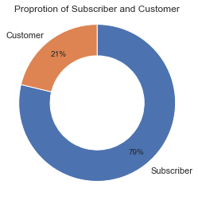

```python
# Pie charts
sorted_counts = df['user_type'].value_counts()
ax=plt.pie(sorted_counts, labels = sorted_counts.index, startangle = 90,
        counterclock = False,pctdistance=0.8 ,wedgeprops = {'width' : 0.4}, autopct='%1.0f%%');
plt.title('Proprotion of Subscriber and Customer')
plt.axis('square');
```

**Observation**: This pie chart shows the proportion of **Subscriber and Customer**.As you can see on the chart 79% of bike user are subscriber and 21% of bike users are Customer.That means Ford Gobike service possesses about 80% regular client of whole user.

## Bivariate Exploration

> In bivariate exploration were 2 variables used for **Folium** plotting

```python
import folium
# visualizing library for mapping
sample = df.sample(10000)

# To set the center of map calculate the average of latitude and longitude stations
lat_start = sample['start_station_latitude'].mean()
long_start = sample['start_station_longitude'].mean()
m=folium.Map([lat_start,long_start],zoom_start=12,tiles="Stamen Toner")

for i in sample.index:
    sub_lat_start = sample.loc[i,"start_station_latitude"]
    sub_long_start = sample.loc[i,"start_station_longitude"]

    title = f"{sample.loc[i,'start_station_name']}"
    color = "blue"

    folium.CircleMarker([sub_lat_start,sub_long_start],
                       radius=3,color=color,tooltip=title).add_to(m)

m
```

[output not shown]

```python
# To set the center of map calculate the average of latitude and longitude of end stations
lat_end = sample['end_station_latitude'].mean()
long_end = sample['end_station_longitude'].mean()
m=folium.Map([lat_start,long_start],zoom_start=12,tiles="Stamen Toner")

for i in sample.index:
    sub_lat_end = sample.loc[i,"end_station_latitude"]
    sub_long_end = sample.loc[i,"end_station_longitude"]

    title = f"{sample.loc[i,'end_station_name']}"
    color = "red"

    folium.CircleMarker([sub_lat_end,sub_long_end],
                       radius=3,color=color,tooltip=title).add_to(m)

m
```

[output not shown]

## Multivariate Exploration

> Using more than 2 variables to show meaningful visualization by **Scatterplot**

```python
user_type=sample['user_type']
user_type.value_counts()

# Regplot with shape variation
plt.subplots(figsize=(15,5))
type_marker =[['Subscriber','o'],['Customer','^']]


for ttype,marker in type_marker:
    plot_data = sample.loc[user_type==ttype]
    ax=sns.regplot(data=plot_data,x='bike_id',y='duration_min',x_jitter=0.04,marker=marker,fit_reg=False);


plt.xlabel('bike_id');
plt.ylabel('duration in min');
plt.title('scattering bike_id with bike duration in min');
plt.legend(['Subscriber','Customer']);
```

[output not shown]

```python
!jupyter nbconvert slide_deck_template.ipynb --to slides --post serve --template output_toggle
```